# Trends in Incarceration Rates in the U.S. (1970-2018)

Anthony Lee

2022-11-08

## Abstract

This report investigates the trends in the growth of the prison population in the U.S. from 1970 - 2018. It explores inequalities in incarceration rates based on location and population. This question is important because it investigates whether certain aspects may lead to higher incarceration rates in some areas.

## Introduction

The data creates a starting point for people to identify and analyze possible causes for the unequal incarceration rates across the U.S. Challenging power requires evidence that outcomes are inequitable across groups. Like what is stated in Data Feminism, public data is important because solving a social issue requires co-liberation. By only focusing on the outcomes, the issue will never be solved because the root cause is never fixed. The root cause is instilled in society which is why co-liberation is so important in solving the issue and maintaining equality. The indirect stakeholders are people who may use the data set in conducting research. They analyze the data for trends to identify conclusions. The direct stakeholders are the people who are collecting and adding to the data. They directly impact the data set. The central values that are engaged is integrity and justice for all. The questions answered in the report are how incarceration rates are correlated to population and which regions in the U.S. have higher incarceration rates. From this data, we are able to identify possible causes of why certain regions have higher incarceration rates.

## Growth of the U.S. Prison Population

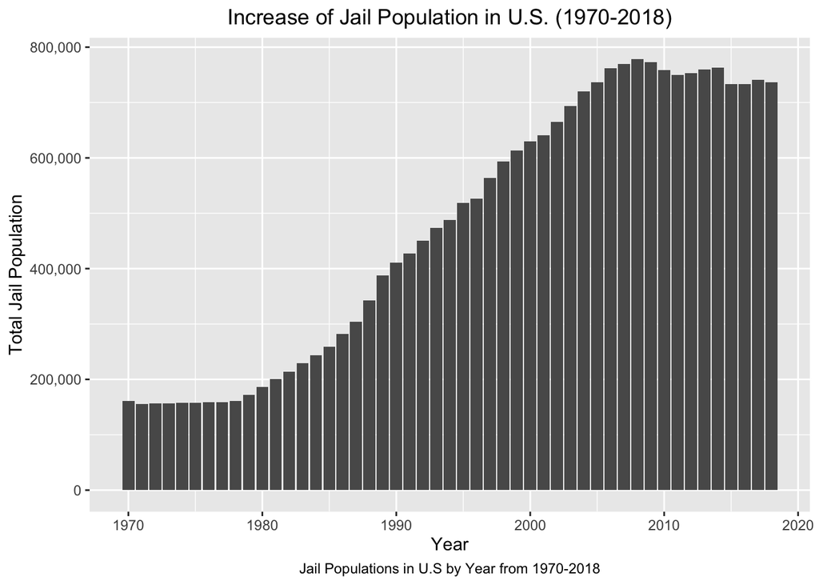

The key pattern revealed by the chart is that incarceration rates have been increasing almost every year from 1970 - 2018. The incarnation rates have more than quadrupled since 1970 from 200,000 to 800,000. The U.S. jail population remained stagnant from 1970 - 1978 and gradually increased until 2008 where it has slightly dropped. This may be due to simply population increases, but outside factors likely play a role too. A question that the chart presents is: **What has caused the incarceration numbers to increase so significantly and will it continue in the future?**

## Growth of the U.S. Prison Population

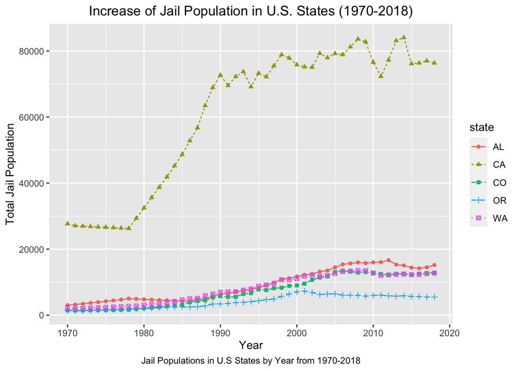

I chose Alabama, Washington, Colorado, Oregon, and California because they are very diverse in location and population. The key pattern revealed in the line chart is that incarceration rates have significantly increased in California since the 1970s. This was probably because of a huge population boom. The incarceration numbers in Washington, Colorado, Oregon, and Alabama have increased slightly. However, Alabama has the second highest incarceration number outside of California even though it’s population count is less than those of Washington and Colorado. A question that the chart presents is: **Why does Alabama have higher incarceration numbers when it has a smaller population?**

## Male vs Female Incarceration in the U.S.

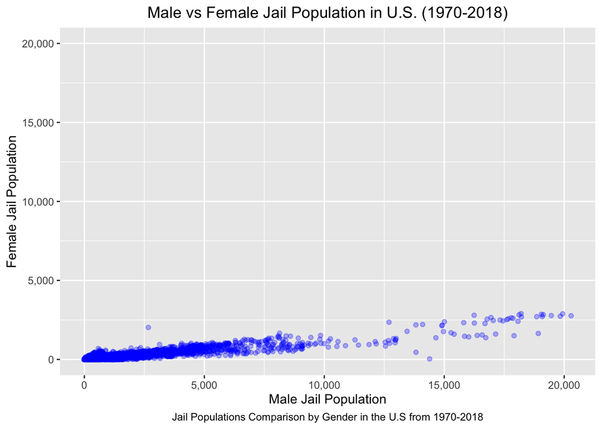

## Incarceration Proportions by State

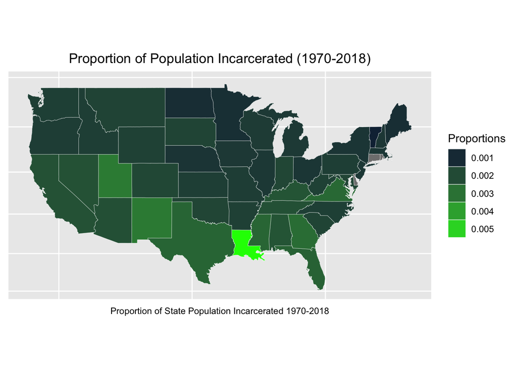

A question that the map answers is: **What states have the highest incarceration rates?** Based on the visualizations it is seen that states in the South and South East of the U.S. have the highest incarceration proportions with Louisiana having the highest proportion of incarceration rate. This is shown through the bright green color that colors the state. Thiso may be because of economic inequality in the U.S. The states located in the North and North Eastern U.S have the lowest incarceration proportions based on the dark green color. The states that have higher incarceration proportions tend to be poorer states which may lead to more crime.